# Instructor Notes 2: Exploratory Data Analysis I

Randi H. Griffin

November 4, 2019

# Introduction

The focus of these notes is on inspecting and cleaning data before feeding it to models. The importance of this task is captured by the dictum, “Garbage in, garbage out”.

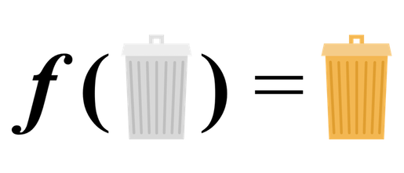

All models have assumptions and limitations. “Garbage in” refers to inputting data that violates critical model assumptions, and “Garbage out” refers to the inaccurate results produced by feeding garbage to your models.

As data scientists, a HUGE part of our job is making sure we aren’t putting garbage into models. In fact, for many of is, this is the most time consuming part of our job!

The process of preparing data for modeling is so important that it deserves to be formalized, which brings us to a core concept of the course: The Inspect-Transform-Inspect workflow (ITI).

### Motivating example

Intuitively, linear regression draws a line through the “middle” of the data. Mathematically, the “middle” is usually defined as the line that minimizes the Sum of the Squared Errors (SSE), or the [least squares line](https://www.mathsisfun.com/data/least-squares-regression.html):

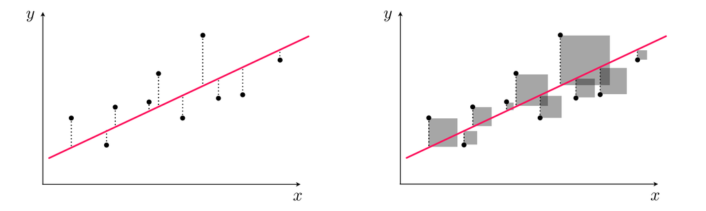

When the errors are scattered evenly around the line (i.e., normally distributed errors), the least squares line produces the most accurate possible predictions. However, when the errors are NOT normally distributed, the least squares line can be misleading. Below, I simulate some data with outliers and skew to demonstrate two common ways in which non-normal errors can confuse linear regression:

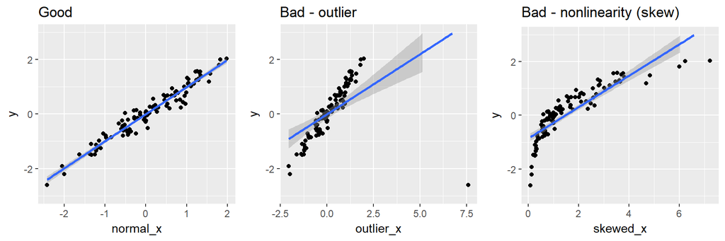

```r
library('tidyverse')
library('gridExtra')

set.seed(23)
n <- 100

# Simulate normally distributed x and y
normal_x <- rnorm(n)
y <- normal_x + rnorm(n, sd=0.25)

# Outlier version of x
outlier_x <- normal_x
outlier_x[which(outlier_x==min(outlier_x))] <- outlier_x[which(outlier_x==min(outlier_x))] + 10

# Skewed version of x
skewed_x <- exp(normal_x)

# Combine variables into dataframe
df <- data.frame(y, normal_x, outlier_x, skewed_x)

# Plot
p1 <- df %>% ggplot(aes(normal_x, y)) + ylim(-3, 3) +
  geom_point() + geom_smooth(method='lm') + ggtitle('Good')
p2 <- df %>% ggplot(aes(outlier_x, y)) + ylim(-3, 3) +
  geom_point() + geom_smooth(method='lm') + ggtitle('Bad - outlier')
p3 <- df %>% ggplot(aes(skewed_x, y)) + ylim(-3, 3) +
  geom_point() + geom_smooth(method='lm') + ggtitle('Bad - nonlinearity (skew)')

# Plot linear regressions
grid.arrange(p1, p2, p3, nrow=1)
```

The first plot above shows a ‘healthy’ linear regression of `y ~ x`, where both `y` and `x` are normally distributed. The middle plot shows what happens to the line if we insert a single severe outlier into `x`, and the plot on the far right shows what happens if we force `x` to be skewed by exponentiating it.

Notice how in both the middle and right plots, the line does not go through the ‘middle’ of the data and the points are not scattered evenly around the line. If we were to use these models to make predictions, they would be extremely biased and inaccurate!

THIS is why we must inspect and transform our data before feeding it into our models. In this case, since we have continuous features, we can inspect them individually with histograms:

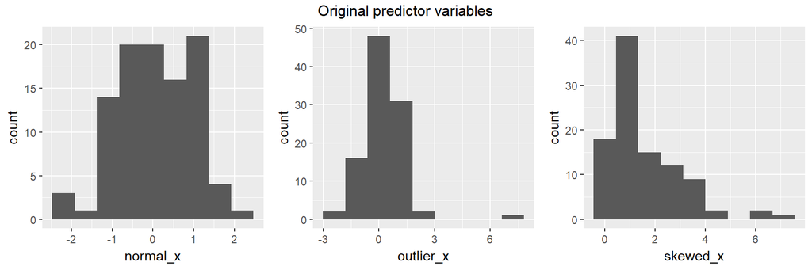

```r
# Plot histograms of the different versions of x
p1 <- df %>% ggplot(aes(x=normal_x)) + geom_histogram(bins=9)
p2 <- df %>% ggplot(aes(x=outlier_x)) + geom_histogram(bins=9)
p3 <- df %>% ggplot(aes(x=skewed_x)) + geom_histogram(bins=9)
grid.arrange(p1, p2, p3, nrow=1, top="Original predictor variables")
```

Now, we can fix the problems with some standard variable transformations and plot the histograms again to show that the variables are ‘fixed’ (don’t worry, we will discuss these transformations shortly):

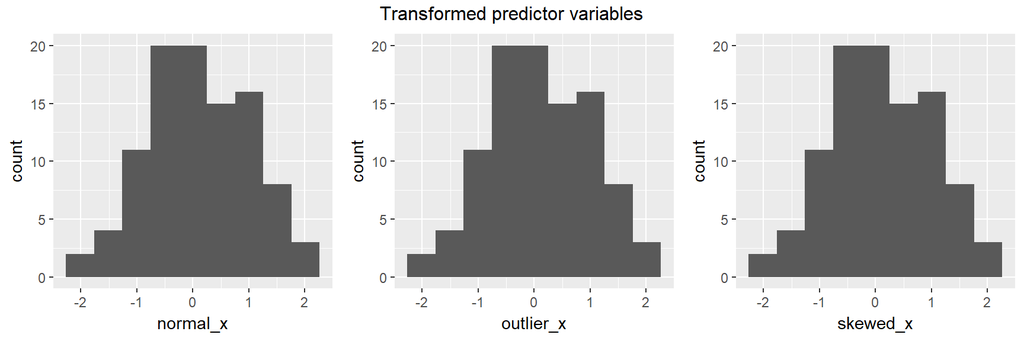

```r
# Drop outliers
df <- df %>% filter(abs(outlier_x) < 5)

# Log tansform the skewed variable
df$skewed_x <- log(df$skewed_x)

# Plot histograms of the transformed versions of x
p1 <- df %>% ggplot(aes(x=normal_x)) + geom_histogram(bins=9)
p2 <- df %>% ggplot(aes(x=outlier_x)) + geom_histogram(bins=9)
p3 <- df %>% ggplot(aes(x=skewed_x)) + geom_histogram(bins=9)
grid.arrange(p1, p2, p3, nrow=1, top="Transformed predictor variables")
```

They all look relatively normal now. Now we can refit the linear regressions on the transformed data and observe that all 3 appear to be healthy linear regressions:

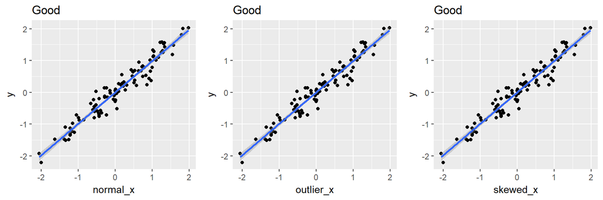

```r
# Plot
p1 <- df %>% ggplot(aes(normal_x, y)) +
  geom_point() + geom_smooth(method='lm') + ggtitle('Good')
p2 <- df %>% ggplot(aes(outlier_x, y)) +
  geom_point() + geom_smooth(method='lm') + ggtitle('Good')
p3 <- df %>% ggplot(aes(skewed_x, y)) +
  geom_point() + geom_smooth(method='lm') + ggtitle('Good')

# Plot linear regressions
grid.arrange(p1, p2, p3, nrow=1)
```

Much better! In the next section, we will generalize the process that unfolded above to other types of variables.

### Inspect-Transform-Inspect workflow (ITI)

The ITI workflow is an iterative process in which you inspect and transform your variables until they are ‘clean’. This messy process is almost always hidden from view in the final version of a data science project, but in reality, it occupies much of your time as an analyst and has a huge impact on the quality of your results. This is the unglamorous part of scientific research in which you painstakingly set up your experiment and obsess over details that could mislead your results:

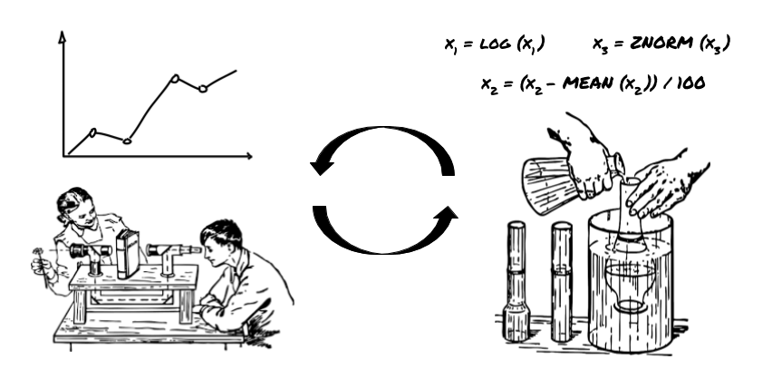

In this course, rather than glossing over the dirty work, we will emphasize and expose it in our assignments. Every variable that you are considering for your models must go through the ITI workflow. You must demonstrate your ability to recognize problems in the data, fix them with code, and communicate your thought process effectively. This is what data science is about!

The workflow for a single variable goes like this:

1. Plot the variable using an appropriate plot type based on the data type. Inspect the plot and interpret what you see with words. Indicate anything interesting you notice and mention any transformations that might needed (if there aren’t any, just say so).
2. Transform the variable, or leave it alone, based on your observations above.
3. Plot a final inspection of the variable to show your reader that the variable is now appropriately transformed and “passes” your inspection.

You can apply this workflow to each variable one at a time. However, an even better approach is to consolidate all of your plots into one “before transformation” panel of plots and one “after transformation” panel of plots, with each panel including a plot for each variable. You can combine arbitrary `ggplot` plots into multi-panel plots using the `grid.arrange` function from the `gridExtra` package, and there are many examples of how to do this in the Instructor Notes. For example, if you have 6 variables to inspect, your report could include:

1. **Initial inspection:** One 2 x 3 panel plot showing each variable prior to transformation. After the plot is a block of narrative text, organized with a bullet point for each of the 6 variables, describing the plots and your ideas for transforming each variable.
2. **Transform**: A block of code that executes the transformations to your variables, based on your observations above.
3. **Final inspection:** Reproduce the 2 x 3 plot, except using the newly transformed variables, to demonstrate how the variables have been changed and improved by the transformations you just did.

Communication is absolutely critical: The ITI workflow is not only a method for *doing* careful work, it is also about *proving to your reader* that you are doing careful work. The reason I recommend consolidating your plots is purely to make it easier to communicate your steps to the reader. In the end, it doesn’t matter how careful you are if you can’t convince your reader. This is very important when you are applying for analyst jobs, because employers want to know that they can trust you to work independently and to put in the effort to not only DO the work, but also SHARE it in a way that is easy for others to understand. It is the exact same reason why companies selling exercise equipment or weight-loss drugs provide before-after photos: You have to show people what the impact is!

In addition, it is important to know that the ITI workflow is not only about finding problems: It can also lead to new questions and insights beyond the original goals of the project. As you go through the workflow, keep an open mind and don’t be afraid to follow up on something unusual or interesting that you notice in your plots, even if it wasn’t part of your original plan. For example, if you see an outlier, a decent analyst recognizes it and removes it, but an excellent analyst digs deeper to explain why the outlier is there in the first place, because that could lead to interesting insights and impress your reader with your thoroughness. Finding hidden value in datasets will make you stand out as an analyst!

In the next section, we discuss the most common types of inspections and transformations for individual variables.

# ITI for individual variables

This week, the focus is on how to inspect and transform *individual variables*. This means that we will only be considering one variable at a time. We will turn our attention to multivariate relationships next week.

Generally speaking, there are two types of inspections: visual and numerical. Visual inspections involve *plots*, while numerical inspections involve *tables* or *summary statistics*. When you first pull a new dataframe into R, the first thing you should do is a quick summary of all the variables to get a big picture idea of what is in the dataset. I like to use the `summary` function, since it shows you a lot of useful information about each variable. Here is an example using the built in `iris` dataset:

```r
# load built-in dataframe
data(iris)

# print summary
iris %>% summary
```

```
##   Sepal.Length    Sepal.Width     Petal.Length    Petal.Width
##  Min.   :4.300   Min.   :2.000   Min.   :1.000   Min.   :0.100
##  1st Qu.:5.100   1st Qu.:2.800   1st Qu.:1.600   1st Qu.:0.300
##  Median :5.800   Median :3.000   Median :4.350   Median :1.300
##  Mean   :5.843   Mean   :3.057   Mean   :3.758   Mean   :1.199
##  3rd Qu.:6.400   3rd Qu.:3.300   3rd Qu.:5.100   3rd Qu.:1.800
##  Max.   :7.900   Max.   :4.400   Max.   :6.900   Max.   :2.500
##        Species
##  setosa    :50
##  versicolor:50
##  virginica :50
##
##
##
```

```r
# print structure
iris %>% str
```

```
## 'data.frame':    150 obs. of  5 variables:
##  $ Sepal.Length: num  5.1 4.9 4.7 4.6 5 5.4 4.6 5 4.4 4.9 ...
##  $ Sepal.Width : num  3.5 3 3.2 3.1 3.6 3.9 3.4 3.4 2.9 3.1 ...
##  $ Petal.Length: num  1.4 1.4 1.3 1.5 1.4 1.7 1.4 1.5 1.4 1.5 ...
##  $ Petal.Width : num  0.2 0.2 0.2 0.2 0.2 0.4 0.3 0.2 0.2 0.1 ...
##  $ Species     : Factor w/ 3 levels "setosa","versicolor",..: 1 1 1 1 1 1 1 1 1 1 ...
```

Take moment to inspect the information output from these two functions. The `summary` function computes summary statistics for continuous variables and counts of categorical variables (although if you have a category with many levels, it will only show you counts a few of them to save space). The `str` function shows you how many observations (rows) and variables (columns) you have, followed by the type of variables (e.g., number or factor), and prints out the first few examples of each variable.

Sometimes, you can notice glaring errors in the data at this stage, such as negative values in a variable that should be all positive (e.g., ‘height’ should never be negative, so if there are negative values). You can also get an early hint that some continuous features are skewed if the mean and the median are very different. The `summary` function also shows you how many missing values are in each row of data, although in this case there are no missing values. But really, the `summary` and `str` functions are just a quick peek at the data before you dive in to inspect each variable with plots.

For the rest of these notes, we are going to focus on visual inspections. What types of plots should you use to inspect individual variables, and how can you fix common problems? It depends on the variable type! Let’s go through each of the four variable types: continuous, ordinal, multinomial, and binary. Finally, the section ends with a discussion of how to handle missing values, which is a common issue that occurs for all data types.